# Panel Estimator DGP Comparisons

This cached ablation compares four panel ATT estimators across a sequence of data-generating processes. The point is not to crown a universal winner; it is to make a failure mode visible. When treatment timing is selected on latent factors, a two-way fixed-effects regression can look precise while estimating the wrong counterfactual trend.

Each Monte Carlo replication generates one panel and sends the **same draw** through four estimators:

- `FixedEffectsOLS`, used as a two-way fixed-effects treatment regression;
- `SyntheticControl`, fit to the average treated unit’s pre-period path;
- `SyntheticDID`, using the panel estimator exposed by `crabbymetrics`;
- `MatrixCompletion`, fit after masking treated post-treatment outcomes and using the completed values as counterfactuals.

All four DGPs have the same true post-treatment ATT, $\tau = 1$. The DGPs differ in whether untreated outcomes are additive or low-rank and in whether treatment is randomly assigned or selected on latent factor loadings.

The page uses Quarto execution caching and freezing, so the Monte Carlo runs once and later site renders reuse the saved output unless this file changes.

## 1 Setup

```python
from dataclasses import dataclass
from html import escape

import matplotlib.pyplot as plt
import numpy as np
from IPython.display import HTML, display

import crabbymetrics as cm

np.set_printoptions(precision=4, suppress=True)


def html_table(headers, rows):
    parts = ["<table>", "<thead>", "<tr>"]
    parts.extend(f"<th>{escape(str(h))}</th>" for h in headers)
    parts.extend(["</tr>", "</thead>", "<tbody>"])
    for row in rows:
        parts.append("<tr>")
        parts.extend(f"<td>{cell}</td>" for cell in row)
        parts.append("</tr>")
    parts.extend(["</tbody>", "</table>"])
    return "".join(parts)


@dataclass(frozen=True)
class DGP:
    key: str
    title: str
    factor_strength: float
    selection: str
    additive_only: bool = False
    nonlinear: bool = False
```

## 2 DGP

The untreated potential outcome is

$$Y_{it}(0) = \alpha_i + \gamma_t + \lambda_i' f_t + \varepsilon_{it},$$

with the factor term omitted in the additive benchmark. In selected-adoption designs, the treated units are more likely to have large latent factor scores. In the strongest design, treatment is assigned to the units with the highest factor-selection score, so parallel trends is deliberately false.

```python
def make_panel(
    rng,
    dgp,
    n_control=48,
    n_treated=6,
    t_pre=20,
    t_post=8,
    tau=1.0,
    noise=0.18,
):
    n = n_control + n_treated
    tt = t_pre + t_post
    time = np.arange(tt)

    alpha = rng.normal(scale=0.8, size=n)
    gamma = 0.06 * time + 0.35 * np.sin(np.linspace(0, 2.2 * np.pi, tt))

    factors = np.column_stack(
        [
            np.linspace(-1.0, 1.0, tt),
            np.sin(np.linspace(0.0, 2.5 * np.pi, tt)),
            np.cos(np.linspace(0.0, 1.7 * np.pi, tt)),
        ]
    )
    loadings = rng.normal(size=(n, factors.shape[1]))
    factor_part = np.zeros((n, tt)) if dgp.additive_only else dgp.factor_strength * (loadings @ factors.T)
    if dgp.nonlinear and not dgp.additive_only:
        factor_part += 0.35 * (loadings[:, [0]] ** 2 - 1.0) @ np.sin(np.linspace(0, 2 * np.pi, tt))[None, :]

    y0 = alpha[:, None] + gamma[None, :] + factor_part + rng.normal(scale=noise, size=(n, tt))

    if dgp.selection == "random" or dgp.additive_only:
        treated_units = rng.choice(n, size=n_treated, replace=False)
    else:
        score = loadings[:, 0] + 0.7 * loadings[:, 1] + 0.25 * alpha
        if dgp.selection == "mild":
            p = np.exp(0.8 * (score - score.mean()) / score.std())
            p = p / p.sum()
            treated_units = rng.choice(n, size=n_treated, replace=False, p=p)
        elif dgp.selection == "strong":
            treated_units = np.argsort(score)[-n_treated:]
        else:
            raise ValueError(dgp.selection)

    treated_units = np.sort(np.asarray(treated_units, dtype=int))
    y = y0.copy()
    y[np.ix_(treated_units, np.arange(t_pre, tt))] += tau
    return y, treated_units.tolist(), t_pre, tau


dgps = [
    DGP("additive", "A. Additive FE / parallel trends", 0.0, "random", additive_only=True),
    DGP("random_factor", "B. Factor structure / random adoption", 0.75, "random"),
    DGP("mild_selection", "C. Factor structure / mild selection", 0.95, "mild"),
    DGP("strong_selection", "D. Factor structure / strong selection", 1.15, "strong", nonlinear=True),
]

display(
    HTML(
        html_table(
            ["Panel", "Factor structure", "Treatment assignment"],
            [[d.title, "none" if d.additive_only else f"strength {d.factor_strength}", d.selection] for d in dgps],
        )
    )
)
```

| Panel | Factor structure | Treatment assignment |
| --- | --- | --- |
| A. Additive FE / parallel trends | none | random |
| B. Factor structure / random adoption | strength 0.75 | random |
| C. Factor structure / mild selection | strength 0.95 | mild |
| D. Factor structure / strong selection | strength 1.15 | strong |

## 3 Estimators

The estimators are intentionally fed identical panels within a replication. `SyntheticDID` and `MatrixCompletion` use the common `fit(Y, W)` panel API: `Y` is the observed panel and `W` is the same-shaped absorbing treatment matrix. `MatrixCompletion` treats the untreated cells (`W == 0`) as observed and reconstructs $Y(0)$ in exactly the treated cells where the ATT is evaluated.

```python
def estimate_twfe(panel, treated_units, t_pre):
    n, tt = panel.shape
    unit = np.repeat(np.arange(n, dtype=np.uint32), tt)
    time = np.tile(np.arange(tt, dtype=np.uint32), n)
    treated = np.zeros(n)
    treated[treated_units] = 1.0
    post = (np.arange(tt) >= t_pre).astype(float)
    d = np.repeat(treated, tt) * np.tile(post, n)
    fe = np.column_stack([unit, time])
    model = cm.FixedEffectsOLS()
    model.fit(d[:, None], fe, panel.reshape(-1))
    return float(np.asarray(model.summary()["coef"])[0])


def estimate_sc(panel, treated_units, t_pre):
    all_units = np.arange(panel.shape[0])
    controls = np.array([i for i in all_units if i not in set(treated_units)], dtype=int)
    donors_pre = panel[np.ix_(controls, np.arange(t_pre))].T
    donors_post = panel[np.ix_(controls, np.arange(t_pre, panel.shape[1]))].T
    treated_pre = panel[np.ix_(treated_units, np.arange(t_pre))].mean(axis=0)
    treated_post = panel[np.ix_(treated_units, np.arange(t_pre, panel.shape[1]))].mean(axis=0)
    model = cm.SyntheticControl(max_iterations=800)
    model.fit(donors_pre, treated_pre)
    return float((treated_post - model.predict(donors_post)).mean())


def treatment_matrix(panel, treated_units, t_pre):
    w = np.zeros_like(panel, dtype=float)
    w[np.ix_(list(treated_units), np.arange(t_pre, panel.shape[1]))] = 1.0
    return w


def estimate_sdid(panel, treated_units, t_pre):
    model = cm.SyntheticDID(zeta_omega=1e-8, zeta_lambda=1e-8, max_iterations=1500)
    model.fit(panel, treatment_matrix(panel, treated_units, t_pre))
    return float(model.summary()["att"])


def estimate_mc(panel, treated_units, t_pre):
    model = cm.MatrixCompletion(lambda_fraction=0.03, max_iterations=500, tolerance=1e-7)
    model.fit(panel, treatment_matrix(panel, treated_units, t_pre))
    return float(model.summary()["att"])


estimators = [
    ("TWFE", estimate_twfe),
    ("SC", estimate_sc),
    ("SDID", estimate_sdid),
    ("MC", estimate_mc),
]
```

## 4 Monte Carlo

```python
def run_mc(reps=160, seed=2026050202):
    rng = np.random.default_rng(seed)
    results = {d.key: {name: [] for name, _ in estimators} for d in dgps}
    failures = {d.key: {name: 0 for name, _ in estimators} for d in dgps}

    for dgp in dgps:
        for _ in range(reps):
            panel, treated_units, t_pre, _tau = make_panel(rng, dgp)
            for name, fn in estimators:
                try:
                    estimate = fn(panel, treated_units, t_pre)
                    if np.isfinite(estimate):
                        results[dgp.key][name].append(estimate)
                    else:
                        failures[dgp.key][name] += 1
                except Exception:
                    failures[dgp.key][name] += 1

    for dgp in dgps:
        for name, _ in estimators:
            results[dgp.key][name] = np.asarray(results[dgp.key][name], dtype=float)
    return results, failures


results, failures = run_mc()
```

## 5 ATT Distribution By DGP

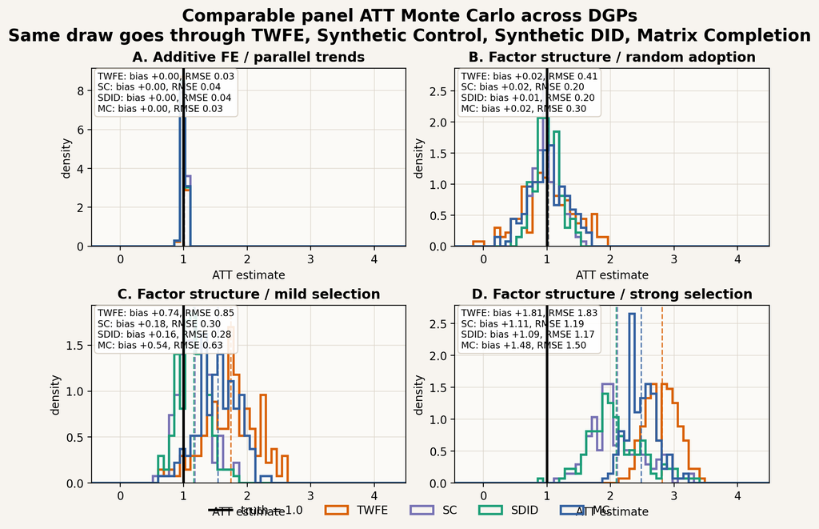

```python
def rmse(vals, truth=1.0):
    return float(np.sqrt(np.mean((vals - truth) ** 2)))


colors = {"TWFE": "#d95f02", "SC": "#7570b3", "SDID": "#1b9e77", "MC": "#315f9f"}
fig, axes = plt.subplots(2, 2, figsize=(9, 6.4), dpi=100, constrained_layout=True)
fig.patch.set_facecolor("#f7f4ef")
bins = np.linspace(-0.5, 4.5, 60)
summary = {}

for ax, dgp in zip(axes.flat, dgps):
    ax.set_facecolor("#fbfaf7")
    ax.axvline(1.0, color="black", lw=2.2, label="truth = 1.0", zorder=5)
    lines = []
    summary[dgp.key] = {}
    for name, _ in estimators:
        vals = results[dgp.key][name]
        ax.hist(vals, bins=bins, histtype="step", linewidth=2.0, color=colors[name], density=True, label=name)
        ax.axvline(vals.mean(), color=colors[name], lw=1.2, ls="--", alpha=0.85)
        bias = float(vals.mean() - 1.0)
        method_rmse = rmse(vals)
        lines.append(f"{name}: bias {bias:+.2f}, RMSE {method_rmse:.2f}")
        summary[dgp.key][name] = {
            "n": int(len(vals)),
            "bias": bias,
            "rmse": method_rmse,
            "failures": failures[dgp.key][name],
        }
    ax.set_title(dgp.title, fontsize=12, weight="bold")
    ax.set_xlim(-0.45, 4.5)
    ax.set_xlabel("ATT estimate")
    ax.set_ylabel("density")
    ax.grid(True, color="#ddd6cc", linewidth=0.8, alpha=0.7)
    ax.text(
        0.02,
        0.98,
        "\n".join(lines),
        transform=ax.transAxes,
        va="top",
        fontsize=8.2,
        bbox=dict(boxstyle="round,pad=.35", facecolor="white", edgecolor="#d8d0c5", alpha=0.88),
    )

handles, labels = axes.flat[0].get_legend_handles_labels()
fig.legend(handles, labels, loc="lower center", ncol=5, frameon=False, bbox_to_anchor=(0.5, -0.01))
fig.suptitle(
    "Comparable panel ATT Monte Carlo across DGPs\nSame draw goes through TWFE, Synthetic Control, Synthetic DID, Matrix Completion",
    fontsize=15,
    weight="bold",
)
plt.show()
```

## 6 Summary Table

```python
rows = []
for dgp in dgps:
    for name, _ in estimators:
        item = summary[dgp.key][name]
        rows.append(
            [
                dgp.title,
                name,
                item["n"],
                f"{item['bias']:+.3f}",
                f"{item['rmse']:.3f}",
                item["failures"],
            ]
        )

display(HTML(html_table(["DGP", "Estimator", "Successful reps", "Bias", "RMSE", "Failures"], rows)))
```

| DGP | Estimator | Successful reps | Bias | RMSE | Failures |
| --- | --- | --- | --- | --- | --- |
| A. Additive FE / parallel trends | TWFE | 160 | +0.004 | 0.029 | 0 |
| A. Additive FE / parallel trends | SC | 160 | +0.003 | 0.036 | 0 |
| A. Additive FE / parallel trends | SDID | 160 | +0.002 | 0.036 | 0 |
| A. Additive FE / parallel trends | MC | 160 | +0.003 | 0.032 | 0 |
| B. Factor structure / random adoption | TWFE | 160 | +0.021 | 0.406 | 0 |
| B. Factor structure / random adoption | SC | 160 | +0.016 | 0.197 | 0 |
| B. Factor structure / random adoption | SDID | 160 | +0.012 | 0.197 | 0 |
| B. Factor structure / random adoption | MC | 160 | +0.016 | 0.300 | 0 |
| C. Factor structure / mild selection | TWFE | 160 | +0.743 | 0.851 | 0 |
| C. Factor structure / mild selection | SC | 160 | +0.179 | 0.297 | 0 |
| C. Factor structure / mild selection | SDID | 160 | +0.158 | 0.277 | 0 |
| C. Factor structure / mild selection | MC | 160 | +0.540 | 0.627 | 0 |
| D. Factor structure / strong selection | TWFE | 160 | +1.813 | 1.830 | 0 |
| D. Factor structure / strong selection | SC | 160 | +1.106 | 1.188 | 0 |
| D. Factor structure / strong selection | SDID | 160 | +1.089 | 1.172 | 0 |
| D. Factor structure / strong selection | MC | 160 | +1.480 | 1.498 | 0 |

## 7 Takeaways

The additive benchmark is deliberately easy: all estimators are centered near the truth. Random adoption under a factor structure is already harder for TWFE because untreated potential outcomes have richer unit-specific time paths; SC and SDID use the pre-period path and are tighter.

The selected-adoption designs are the main diagnostic. Once treatment is selected on latent factors, TWFE inherits the wrong counterfactual trend and drifts upward. SC and SDID are not magic—the strong nonlinear-selection DGP is hard for them too—but they degrade more gracefully because they explicitly match or reweight pre-treatment panel paths. In these settings, the current matrix-completion default is more fragile than SDID, which is useful information for tuning and API examples rather than a final statement about the estimator class.